# Chi-square

July 24, 2017

Notes and examples are from: [Predictive HR Analytics: Mastering the HR Metric. by Martin R Edwards and Kirsten Edwards](https://www.amazon.com/Predictive-HR-Analytics-Mastering-Metric/dp/0749473916).

## Example 1: Gender and Job Grade Analysis Using Frequency Tables and Chi-Square

Load in the data.

```r
rm(list = ls())
diverse = read.csv("http://fdrennan.net/pages/pages2/datasets/ch4Diversity1.csv")
```

Here, we will make a plot of each column to look at the characteristics of each column. We are going to check for possible discrimination or unconscious bias within the organization.

We see that there are 1,493 employees.

```r
nrow(diverse)
```

```
## [1] 1493
```

Of these employees, there are 746 females and 745 males. The organization I balanced between male and female employees, though it may not be balanced across pay grades. In this example, we will example whether this even representation exists throughout all job grades (`diversity$JobGrade`) in the company. We find that there are eight job grades.

```r
apply(diverse, 2, table)
```

```
## $BossGender
##
##    1    2
##  470 1023
##
## $Gender
##
##   1   2
## 746 745
##
## $JobGrade
##
##   1   2   3   4   5   6   7   8
##  39 343 265 243 250 239  81  33
##
## $Age
##
## 16 17 18 19 20 21 22 23 24 25 26 27 28 29 30 31 32 33 34 35 36 37 38 39 40
##  2  1  5  5  2 10 11 35 28 31 35 49 48 51 54 56 56 58 61 42 52 34 49 53 49
## 41 42 43 44 45 46 47 48 49 50 51 52 53 54 55 56 57 58 59 60 61 62 63 64 66
## 37 56 43 56 41 42 48 45 44 36 35 26 26 12 15 15  8  9  5  7  4  2  1  2  1
##
## $Tenure
##
##   0   1   2   3   4   5   6   7   8   9  10  11  12  13  14  15  16  17
## 199 109 117  53  74 109  82  58  63  48  24  68  47  35  40  42  15  11
##  18  19  20  21  22  23  24  25  26  27  28  29  30  31  32  33  34  35
##  11  13   2   2  20  27  21  32  27  22  13  18  14   4  17  16  15   9
##  36  37  38  39  40  41  42
##   3   4   2   4   1   1   1
##
## $Status
##
##    1    2    3    4    5
## 1347    2  110    5   29
##
## $PerformanceScore
##
##    4    5
## 1118  172
##
## $BossPerformance
##
##   2   3   4   5
##  12 511 767 159
##
## $Division
##
##   1   2   3   4   5   6   7   8   9  10  11  12
## 239  50   3  68  21  20   9  13  33 602 207 228
##
## $Country
##
##    1    2    3    4    5    6    7    8    9   10
##    5   28   66   33    6    2   73  212 1056   12
##
## $leaver
##
##    1    2
## 1381  110
```

Here, I create factors and levels for each column we decide to analyze. This will give us a better representation of the data. Instead of reading integers we can read what the integers represent.

```r
JobCategories = c("Clerical/Officer", "Administrator/Assistant",
                  "Graduate/Trainee Consultant", "Consultant", "Senior Consultant",
                  "Managing Consultant", "Principal Consultant", "Partner")

BossGend = c("Female", "Male")
gender = c("Female", "Male")

diverse$JobGrade = as.factor(diverse$JobGrade)
diverse$BossGender = as.factor(diverse$BossGender)
diverse$Gender = as.factor(diverse$Gender)

levels(diverse$JobGrade) = JobCategories
levels(diverse$BossGender) = BossGend
levels(diverse$Gender) = gender
```

```r
library(ggplot2)
library(ggthemes)
```

We next built a table between `JobGrade` and `Gender` and plot a bar chart to visually inspect the degree to which gender is represented the organization.

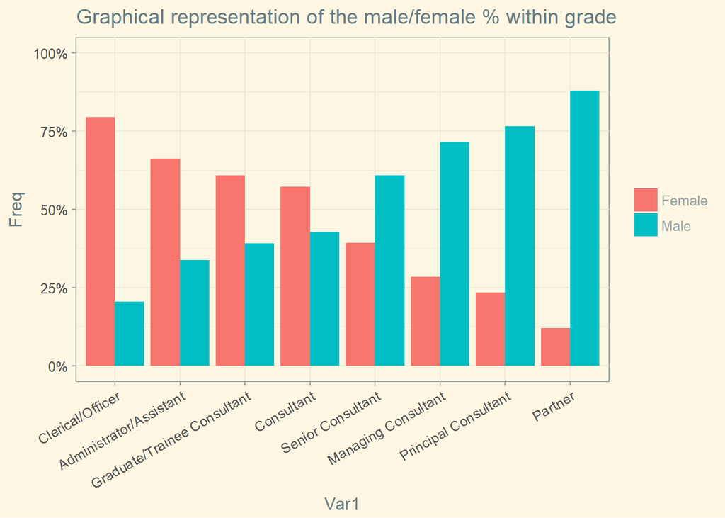

```r
mydf <- data.frame(prop.table(table(diverse$JobGrade, diverse$Gender),1))
ggplot(mydf, aes(Var1, Freq, fill = Var2)) +
    geom_bar(position = "dodge", stat = "identity") +
    scale_y_continuous(labels=scales::percent, limits = c(0, 1)) +
      labs(title = "Graphical representation of the male/female % within grade") +
  theme_solarized() +
  theme(legend.position = "right", legend.title = element_blank()) +
  theme(axis.text.x = element_text(angle = 30, hjust = 1))
```

We see that women are greatly under-represented in top levels of the company and overrepresented in lower levels.

One of the problems with the type of analysis above is that the data has not been subject to analysis. There appears to be a strong pattern, but we cannot yet state that there is a diversity and inclusion bias.Therefore, it is imperative that the HR professional adequately analyzes the data.

### The chi-square test

The chi square is a simple test that we can use to interrogate the patterns presented in the graph shown above. This test will immediately tell the analyst how certain they can be that the pattern is statistically meaningful. It will tell the HR analyst whether such a pattern could be a fluke or due to change alone. Or, putting it another way, it will tell the HR analyst that this is not a fluke and is not due to chance alone, and is, therefore, something that should not be ignored.

The test follows a simple idea. It checks whether the data pattern found is what we would expect to find if there was no link between gender and seniority in our organization. It tells the reader whether there is evidence that a gender bias might exist.

A chi-swuare test enables us to check the actual frequencies of males and females in each job grade within our organization against what we would expect to have if there were no bias.

A no bias scenario, given an approximately equal distribution of male/female employees is below.

```r
proportions = table(diverse$Gender)/sum(table(diverse$Gender))
expectedFemale = as.vector(table(diverse$JobGrade)*proportions[1])
expectedMale = as.vector(table(diverse$JobGrade)*proportions[2])
expectedGender = data.frame(Female = expectedFemale,
                            Male = expectedMale,
                            NumberInRole = as.vector(table(diverse$JobGrade)))

expectedGender = round(expectedGender, 0)

rownames(expectedGender) = JobCategories

print("A no bias scenario")
```

```
## [1] "A no bias scenario"
```

```r
as.matrix(expectedGender)
```

```
##                             Female Male NumberInRole
## Clerical/Officer                20   19           39
## Administrator/Assistant        172  171          343
## Graduate/Trainee Consultant    133  132          265
## Consultant                     122  121          243
## Senior Consultant              125  125          250
## Managing Consultant            120  119          239
## Principal Consultant            41   40           81
## Partner                         17   16           33
```

```r
print("Actual")
```

```
## [1] "Actual"
```

```r
NumberInRole = as.vector(table(diverse$JobGrade))
cbind(table(diverse$JobGrade, diverse$BossGender), NumberInRole)
```

```
##                             Female Male NumberInRole
## Clerical/Officer                14   25           39
## Administrator/Assistant        144  199          343
## Graduate/Trainee Consultant    127  138          265
## Consultant                      62  181          243
## Senior Consultant               63  187          250
## Managing Consultant             45  194          239
## Principal Consultant            10   71           81
## Partner                          5   28           33
```

The percentage within gender (x) is prop.row and the percentage within JobGrade (y) is prop.col. prop.tbl gives the percent total of both male/female employees. That is, the total percentage of employees within each JobGrade.

```r
library(descr)
cross = CrossTable(diverse$Gender, diverse$JobGrade, expected = TRUE, chisq = TRUE)
cross
```

```
##    Cell Contents
## |-------------------------|
## |                       N |
## |              Expected N |
## | Chi-square contribution |
## |           N / Row Total |
## |           N / Col Total |
## |         N / Table Total |
## |-------------------------|
##
## ========================================================================================
##           diverse$JobGrade
## dvrs$G    Clrc/O   Admn/A   Gr/T C   Cnsltn   Snr Cn   Mngn C   Prnc C   Partnr    Total
## ----------------------------------------------------------------------------------------
## Female        31      227      160      139       98       68       19        4      746
##             19.5    171.6    131.6    121.6    125.1    119.6     40.5     16.5
##            6.762   17.874    6.135    2.495    5.864   22.249   11.435    9.480
##            0.042    0.304    0.214    0.186    0.131    0.091    0.025    0.005    0.500
##            0.795    0.662    0.608    0.572    0.392    0.285    0.235    0.121
##            0.021    0.152    0.107    0.093    0.066    0.046    0.013    0.003
## ----------------------------------------------------------------------------------------
## Male           8      116      103      104      152      171       62       29      745
##             19.5    171.4    131.4    121.4    124.9    119.4     40.5     16.5
##            6.771   17.898    6.143    2.499    5.872   22.279   11.450    9.493
##            0.011    0.156    0.138    0.140    0.204    0.230    0.083    0.039    0.500
##            0.205    0.338    0.392    0.428    0.608    0.715    0.765    0.879
##            0.005    0.078    0.069    0.070    0.102    0.115    0.042    0.019
## ----------------------------------------------------------------------------------------
## Total         39      343      263      243      250      239       81       33     1491
##            0.026    0.230    0.176    0.163    0.168    0.160    0.054    0.022
## ========================================================================================
##
## Statistics for All Table Factors
##
## Pearson's Chi-squared test
## ------------------------------------------------------------
## Chi^2 = 164.6992      d.f. = 7      p <2e-16
```

Example Conversation:

CEO: ‘Well, the gender proportions vary quite a bit so that data could easily be coincidence.’

HR analyst: ’It’s no coincidence. If you look at this chi-square test checking for statistical significance, you can see that the chance of this being coincidence is nearly 0. We have a problem and, with further analysis into what the contributing factors may be, my team has some suggestions for how to address it.

CEO: “Thanks, you’re a genious.”